# Predict the mileage of Cars

## Data exploration

```r
# do read table, since data file is .data file
cars <- read.table("./data/auto-mpg.data")
# all the factors seem self-explanatory. Unfortunately we don't know what area the numbers in origin correspond to
# column names were present in the website
colnames(cars) <- c("mpg","cylinders","displacement","horsepower","weight","acceleration","model_year","origin","car_name")
str(cars)
```

```
## 'data.frame':    398 obs. of  9 variables:
##  $ mpg         : num  18 15 18 16 17 15 14 14 14 15 ...
##  $ cylinders   : int  8 8 8 8 8 8 8 8 8 8 ...
##  $ displacement: num  307 350 318 304 302 429 454 440 455 390 ...
##  $ horsepower  : Factor w/ 94 levels "?","100.0","102.0",..: 17 35 29 29 24 42 47 46 48 40 ...
##  $ weight      : num  3504 3693 3436 3433 3449 ...
##  $ acceleration: num  12 11.5 11 12 10.5 10 9 8.5 10 8.5 ...
##  $ model_year  : int  70 70 70 70 70 70 70 70 70 70 ...
##  $ origin      : int  1 1 1 1 1 1 1 1 1 1 ...
##  $ car_name    : Factor w/ 305 levels "amc ambassador brougham",..: 50 37 232 15 162 142 55 224 242 2 ...
```

horsepower is treated as categorical for some reason, it should be numeric. So we convert it into numeric

```r
cars$horsepower <- as.numeric(levels(cars$horsepower))[cars$horsepower]
cars <- na.omit(cars)

# make all the clomns global variables
attach(cars)
```

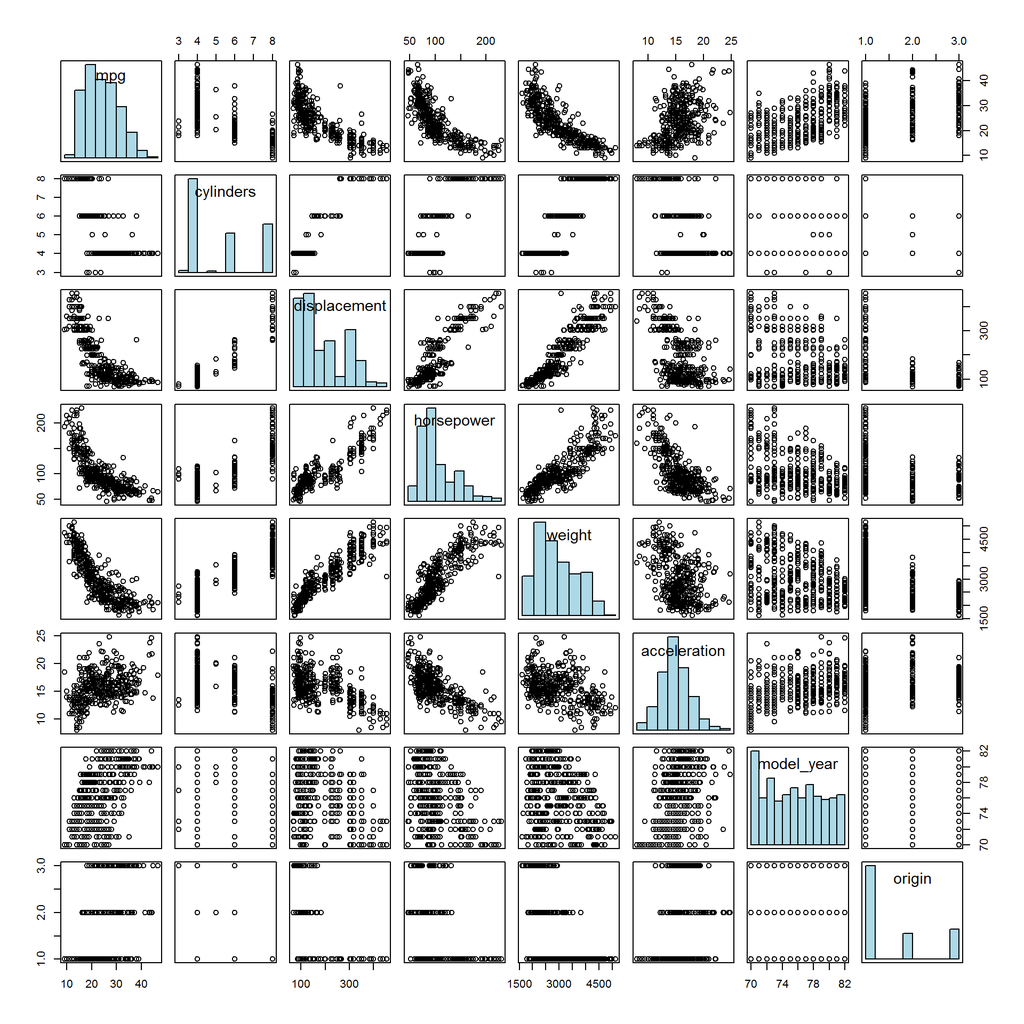

```r
# scatter plot matrix between the numerical variables
# display the the distribution of the variables
# The way to read it is: x-axis is the variable in that colum and axis is the vairable in the row
pairs(~mpg + cylinders + displacement + horsepower + weight + acceleration + model_year+origin,
      diag.panel = function(x, ...) {
        par(new = TRUE)
        hist(x, col = "light blue", main = "", axes = FALSE)
      })
```

From the graph above we can see there is a possible negative correlation between mpg and displacment, and a postive corelation between displacement and weight. There is also a negative corelation between weight and mpg

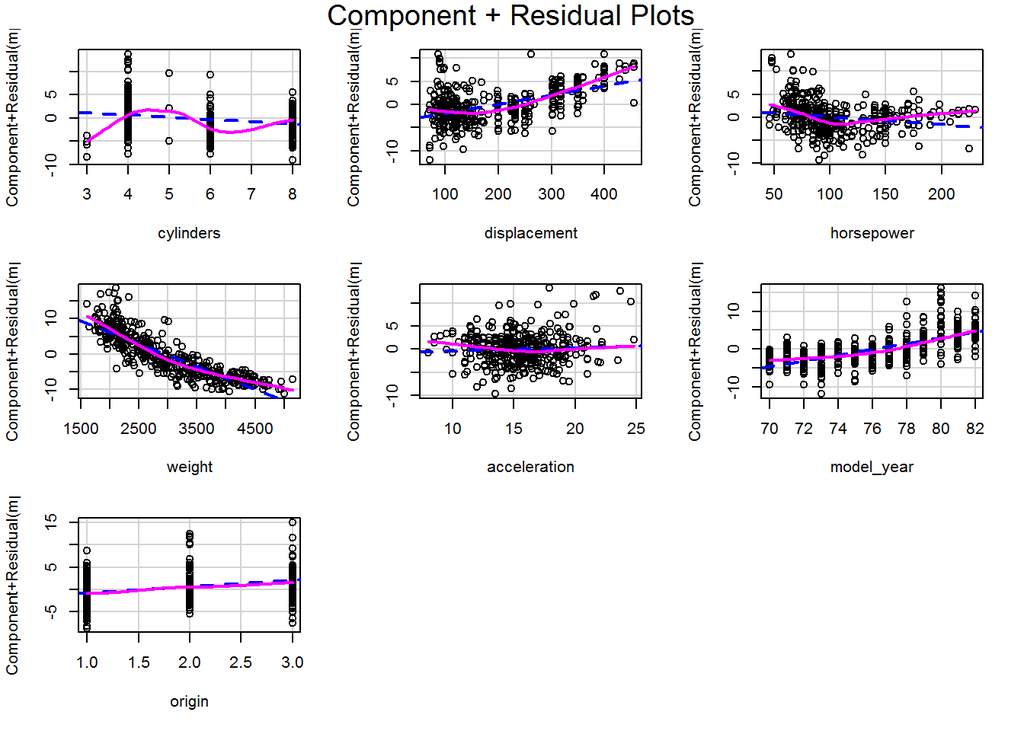

```r
# call an inital regression model
# car name should not have any relevance
# This model creates an equation to predict the dependent variable
# outlier test?
cars.fit <- lm(mpg ~ . -car_name, data=cars)
# plots various graphs of the model including the residual vs fitted graph
# plot(cars.fit)

# Evaluate Nonlinearlity
# component + residueal plot
crPlots(cars.fit)
```

```r
summary(cars.fit)
```

```
##
## Call:
## lm(formula = mpg ~ . - car_name, data = cars)
##
## Residuals:
##     Min      1Q  Median      3Q     Max
## -9.5903 -2.1565 -0.1169  1.8690 13.0604
##
## Coefficients:
##                Estimate Std. Error t value Pr(>|t|)
## (Intercept)  -17.218435   4.644294  -3.707  0.00024 ***
## cylinders     -0.493376   0.323282  -1.526  0.12780
## displacement   0.019896   0.007515   2.647  0.00844 **
## horsepower    -0.016951   0.013787  -1.230  0.21963
## weight        -0.006474   0.000652  -9.929  < 2e-16 ***
## acceleration   0.080576   0.098845   0.815  0.41548
## model_year     0.750773   0.050973  14.729  < 2e-16 ***
## origin         1.426141   0.278136   5.127 4.67e-07 ***
## ---
## Signif. codes:  0 '***' 0.001 '**' 0.01 '*' 0.05 '.' 0.1 ' ' 1
##
## Residual standard error: 3.328 on 384 degrees of freedom
## Multiple R-squared:  0.8215, Adjusted R-squared:  0.8182
## F-statistic: 252.4 on 7 and 384 DF,  p-value: < 2.2e-16
```

- The coefficient t-value is a measure of how many standard deviations our coefficient estimate is far away from 0. if it is relatively far from 0, we could conclude that the variable has a relationship with the independent variable variables
- P-values for coefficients of cylinders, horsepower and acceleration are all greater than 5%.
- This means that the relationship between the dependent and these independent variables is not significant. I’ll drop 2 of these variables and try again. High
- p-values for these independent variables do not mean that they definitely should not be used in the model. It could be that some other variables are correlated with these variables and making these variables less useful for prediction

```r
cars.fit1 <- lm(mpg ~ displacement + horsepower + weight , data=cars)
summary(cars.fit1)
```

```
##
## Call:
## lm(formula = mpg ~ displacement + horsepower + weight, data = cars)
##
## Residuals:
##      Min       1Q   Median       3Q      Max
## -11.3347  -2.8028  -0.3402   2.2037  16.2409
##
## Coefficients:
##                Estimate Std. Error t value Pr(>|t|)
## (Intercept)  44.8559357  1.1959200  37.507  < 2e-16 ***
## displacement -0.0057688  0.0065819  -0.876  0.38132
## horsepower   -0.0416741  0.0128139  -3.252  0.00125 **
## weight       -0.0053516  0.0007124  -7.513 4.04e-13 ***
## ---
## Signif. codes:  0 '***' 0.001 '**' 0.01 '*' 0.05 '.' 0.1 ' ' 1
##
## Residual standard error: 4.241 on 388 degrees of freedom
## Multiple R-squared:  0.707,  Adjusted R-squared:  0.7047
## F-statistic:   312 on 3 and 388 DF,  p-value: < 2.2e-16
```

*Here we see that both Multiple R-squared and Adjusted R-squared have fallen.* When comparing models, use Adjusted R-squared. That’s because R-squared will increase or stay the same (never decrease) when more independent variables are added. The formula for *Adjusted R-squared includes an adjustment to reduce R-squared. If the additional variable adds enough predictive information to the model to counter the negative adjustment then* Adjusted R-squared will increase. If the amount of predictive information added is not valuable enough, Adjusted R-squared will reduce.

```r
#Trying more combinations as acceleration has very high p-value.

# cars.fit3 <- lm(mpg ~ model_year + horsepower + weight, data = cars)
# summary(cars.fit3)


# cars.fit4 <- lm(mpg ~ model_year + horsepower + weight + origin, data = cars)
# summary(cars.fit4)


# cars.fit5 <- lm(mpg ~ model_year + acceleration + weight + origin, data = cars)
# summary(cars.fit5)

# cars.fit6 <- lm(mpg ~ model_year + weight + origin, data = cars)
# summary(cars.fit6)
#Now we're getting somewhere as all the coefficients have a small p-value.

# cars.fit7 <- lm(mpg ~ I(displacement^2) + model_year + weight + origin, data = cars)
# summary(cars.fit7)
#Let's try some non-linear combinations with different exponents for horsepower.
# cars.fit8 <- lm(mpg ~ I(horsepower^1) + I(horsepower^2) + I(horsepower^3) +
#                   model_year + weight + origin, data = cars)
# summary(cars.fit8)

#The Adjusted R-squared is the highest so far. Another thing to note is that even though
#the p-value for horsepower^3 is very small (relationship is significant), the coefficient
#is tiny. So we should consider removing it unless horsepower^3 has an intuitive or business
#meaning to us in the given context.

#While creating models we should always bring business understanding into consideration.
#If the context dictates that that particular variable is important to explaining the outcome,
#we will retain it in the model even if the coefficient is very small.

#If the effect is small and we are not able to explain why the independent variable should
#affect the dependent variable in a particular way, we may be risking overfitting to our
#particular sample of data. Such a model may not generalize.

# cars.fit9 <- lm(mpg ~ horsepower + model_year + weight + origin, data = cars)
#
# summary(cars.fit9)

#Adjusted R-squared reduced. We can do better.

cars.fit10 <- lm(mpg ~ model_year + weight + origin + poly(horsepower,2) , data=cars)
summary(cars.fit10)
```

```
##
## Call:
## lm(formula = mpg ~ model_year + weight + origin + poly(horsepower,
##     2), data = cars)
##
## Residuals:
##     Min      1Q  Median      3Q     Max
## -8.4036 -1.9444 -0.2623  1.7355 12.0573
##
## Coefficients:
##                        Estimate Std. Error t value Pr(>|t|)
## (Intercept)          -2.177e+01  3.654e+00  -5.959 5.73e-09 ***
## model_year            7.456e-01  4.618e-02  16.145  < 2e-16 ***
## weight               -4.393e-03  4.213e-04 -10.426  < 2e-16 ***
## origin                1.046e+00  2.376e-01   4.405 1.37e-05 ***
## poly(horsepower, 2)1 -2.615e+01  6.712e+00  -3.896 0.000115 ***
## poly(horsepower, 2)2  2.998e+01  3.270e+00   9.170  < 2e-16 ***
## ---
## Signif. codes:  0 '***' 0.001 '**' 0.01 '*' 0.05 '.' 0.1 ' ' 1
##
## Residual standard error: 3.036 on 386 degrees of freedom
## Multiple R-squared:  0.8506, Adjusted R-squared:  0.8487
## F-statistic: 439.5 on 5 and 386 DF,  p-value: < 2.2e-16
```

- The adjusted R-squared is the 2nd hieghest.
- None of the coefficients are very small, even though the coefficient for weight is small, the values of weight are in thousands
- the P values in the 95% confidence intervals are also small, so we can have confidence in the coefficeints
- The relationship is non-linear between mpg and horsepower
- Surprsingly origin has a significant effect on mpg

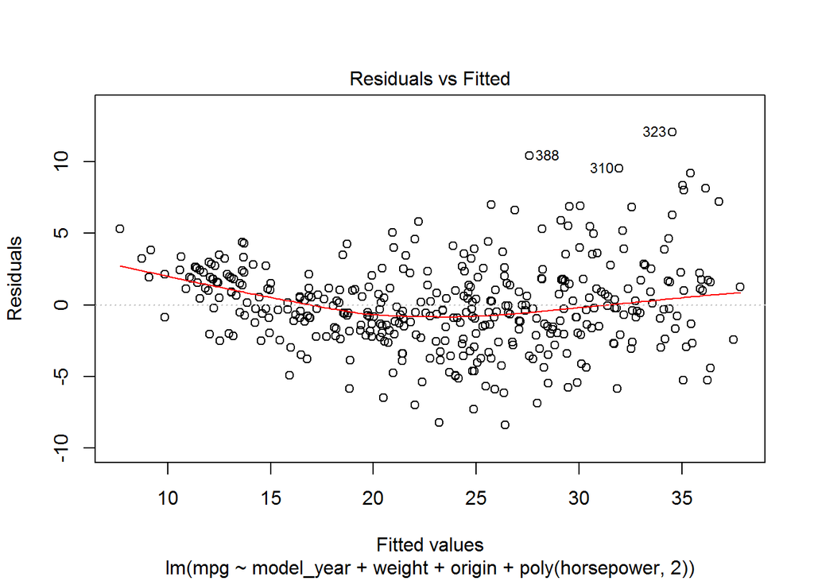

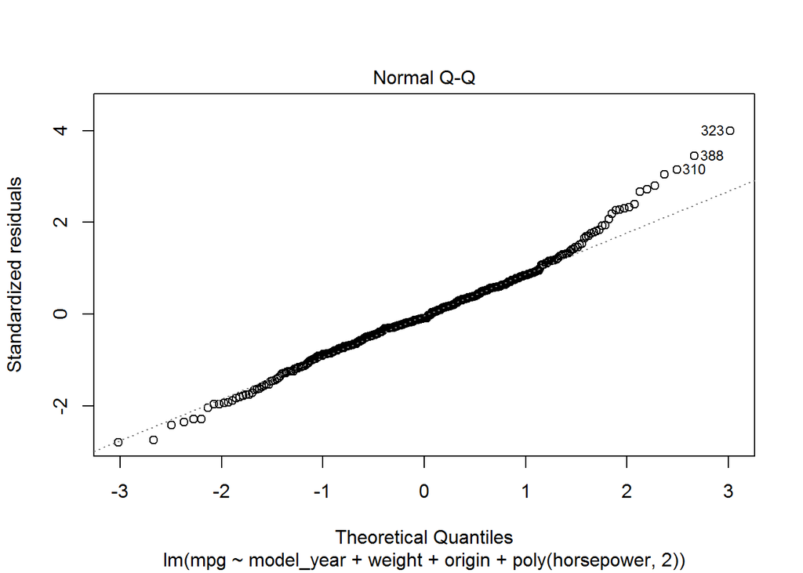

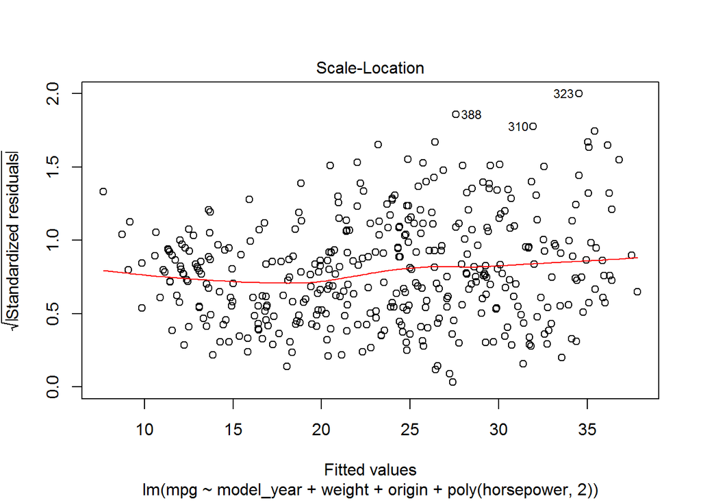

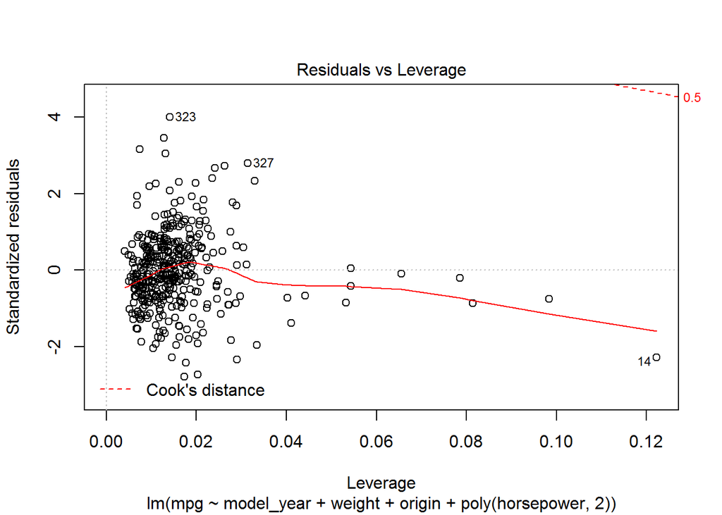

```r
plot(cars.fit10)
```